# Econometria Aplicada à Finanças Aula 4

Mestrado Profissional em Administração

Prof. Washington Santos da Silva

IFMG - Campus Formiga

9 de setembro de 2025

## Diário de Bordo

**O que vimos até o momento?**

- Aula 1 ✅
  - Apresentação da Disciplina ✅
  - Introdução ao RStudio ✅
  - Configurando o Projeto da Disciplina ✅
  - Conheça e Utilize o Terminal Git Bash ✅
- Aula 2 ✅
  - Git e GitHub: Visão Geral ✅
  - Introdução ao Sistema: Visão Geral ✅
  - Linguagem R: Visão Geral ✅
  - Sessão Prática 1 ✅
- Aula 3 ✅
  - Minicurso Intensivo: Teoria da Probabilidade - Parte 1 ✅
    - Introdução à Teoria da Probabilidade ✅
    - Variáveis Aleatórias e Distribuições de Probabilidade ✅
    - Distribuições Conjunta, Marginal e Condicional ✅
    - Independência de Variáveis Aleatórias ✅

## Nesta Aula

**Minicurso Intensivo sobre Teoria da Probabilidade - Parte II**

- Conceitos Básicos: Revisão
- Momentos de Distribuições de Probabilidade Univariadas
- Funções de Variáveis Aleatórias
- Fundamentos de Distribuições de Probabilidade Multivariadas
- Cálculo Diferencial e Integral em R

## Arquivo para esta Aula: `03-relatorio.zip`

**Opção 1: Processo Manual**

- Site da disciplina: https://washingtonsilva.github.io/site_mpa_ecnt2025/cronograma.html
- **Opcão 1:**
- Abra o Rstudio e o seu projeto da disciplina
- Crie a subpasta **relatorios/03-relatorio/**
- baixe, descompacte e mova manualmente o arquivo `03-relatorio.qmd` para a subpasta **relatorios/03-relatorio/** e o arquivo `hansen-wage.rds` para a subpasta **dados/brutos/**

**Diretrizes para Aulas Mais Produtivas**

⌨️ **Código com método:**

95% dos erros são evitáveis com:

- Respeitar a sequência lógica de etapas
- Revisão antes de pedir ajuda
- Atenção na digitação

🤝 **Inteligência colaborativa:**

- Compartilhe conhecimento
- Resolva questões técnicas simples com colegas próximos
- Reserve ao professor as dúvidas conceituais complexas

💪 **Capacidade de Resolver Problemas**

Cada problema/erro resolvido é uma evolução da sua habilidade analítica

# Conceitos Básicos: Revisão

## Variável Aleatória

**Definição**

- Na prática, é conveniente/importante representar resultados de processsos aleatórios numericamente.
- Se o resultado for unidimensional, chamamos o resultado de **variável aleatória**.
- Se o resultado for multidimensional, o chamamos de **vetor aleatório**.
- Variáveis aleatórias são um dos conceitos mais importantes e centrais da teoria da probabilidade. É tão central que, na maioria das vezes, não pensamos em seus fundamentos.
- Como exemplo, considere um cara ou coroa com os possíveis resultados $H$ (Cara) ou $T$ (Coroa).
- Podemos escrever o resultado numericamente definindo o resultado como $X = 1$ se for cara e $X = 0$ se a moeda for coroa.

## Variável Aleatória

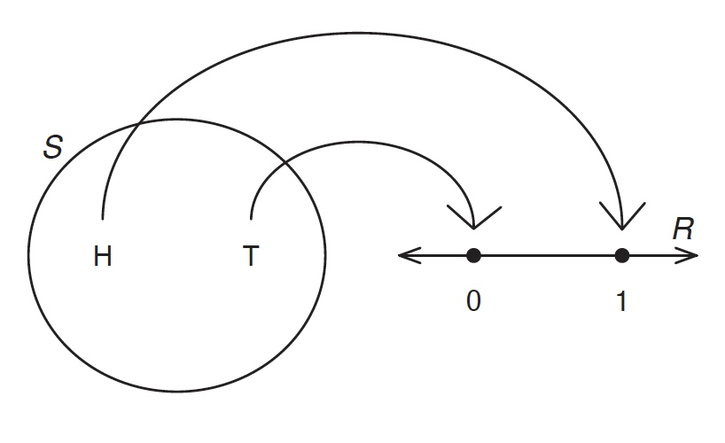

Uma variável aleatória é uma **função** que mapeia resultados de $S$ para $\mathbb{R}$.

## Função de Probabilidade

**Definição**

Para uma VA $X$, uma função $f(x)$ é uma função densidade de probabilidade se:

1. $f(x) \geq 0$ para todo
2. $\int_{-\infty}^{\infty} f(x) \, dx = 1$

Uma densidade é uma função não negativa que é integrável e se integra a um. Pelo teorema fundamental do cálculo, temos a relação:

$$P(a \leq X \leq b) = \int_{a}^{b} f(x) \, dx$$

O que implica que a probabilidade de $X$ estar no intervalo $[a,b]$ é a integral da densidade sobre $[a,b]$.

Isso mostra que a área abaixo da função densidade são probabilidades.

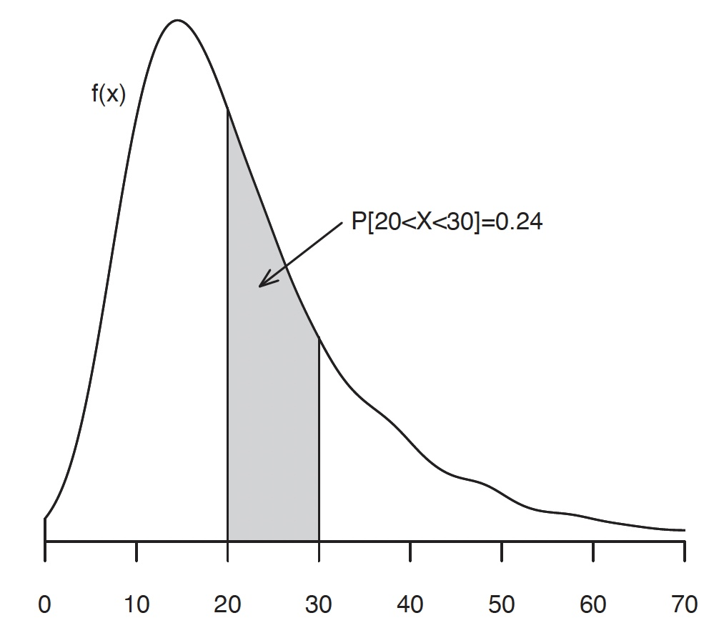

#### Cálculo de Probs. com fdp e FDA

$$\begin{align*}
P(20 < x < 30) &= F(30) - F(20), \\
&= P(X \leq 30) - P(X \leq 20)
\end{align*}$$

## Função de Distribuição Acumulada

**Definição**

- Uma VA pode ser representada por sua função de distribuição (ou função de distribuição acumulada, FDA).
- A função de distribuição acumulada (FDA), $F_X$ , de uma VA $X$ é definida para cada $x$ como:

$$F_X(x) = P(X \leq x)$$

#### Propriedades

1. $0 \leq F_X(x) \leq 1$
2. $F_X(x)$ é não-decrescente em $x$
3. $\lim_{x \to -\infty} F_X(x) = 0$
4. $\lim_{x \to \infty} F_X(x) = 1$

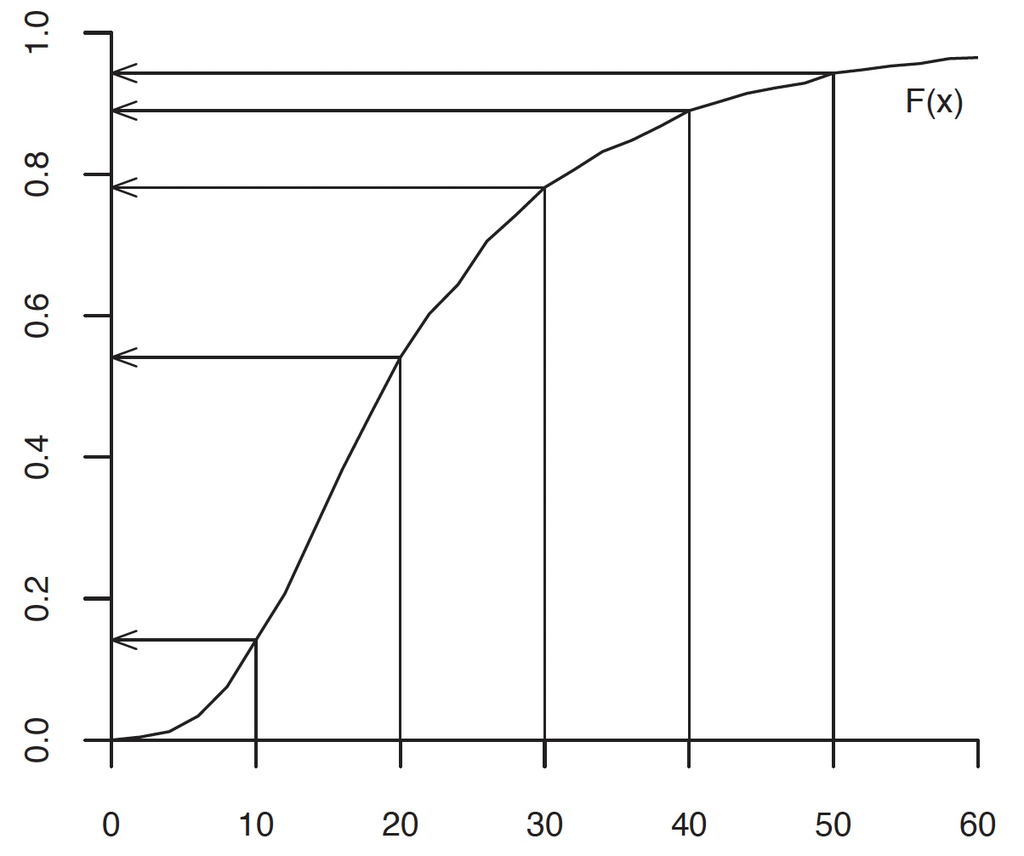

#### Implicações

Uma implicação é que para VAs contínuas, temos as seguintes igualdades:

$$\begin{align*}
P(X < x) = P(X \leq x) &= F(x) \\
P(X > x) = P(X > x) &= 1 - F(x) \\
\end{align*}$$

## Quantis

**Definição**

Para uma distribuição contínua $F(x)$ os quantis $q(\alpha)$ são definidos como as soluções da função:

$$\alpha = F(q(\alpha))$$

Efetivamente, eles são o inverso de $F(x)$:

$$q(\alpha) = F^{-1}(\alpha)$$

Assim, a função quantil $q(\alpha)$ é uma função de $[0,1]$ para o suporte de $X$.

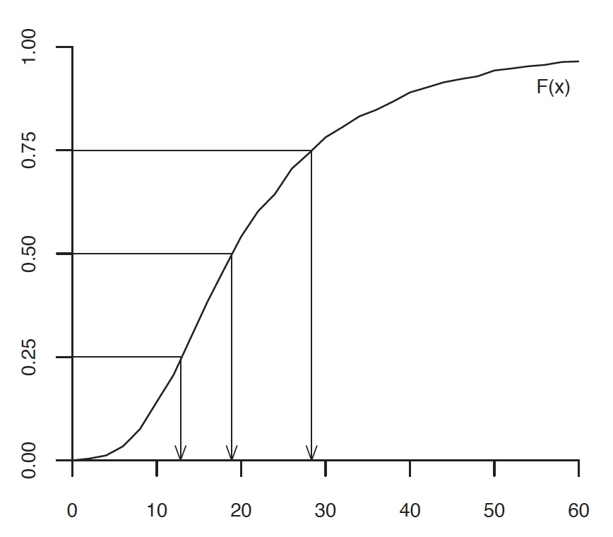

Alguns quantis têm nomes especiais:

- A **mediana** da distribuição é o quantil 0,5.
- Os **quartis** são os quantis 0,25, 0,50 e 0,75. São chamados de quartis por que dividem a população em quatro grupos iguais. A mediana é o segundo quartil.
- Os **decis** são os quantis 0,1, 0,2, …, 0,9 e dividem a população em dez grupos iguais.
- Os **percentis** são os quantis 0,01, 0,02, …, 0,99 e dividem a população em cem grupos iguais. Por exemplo, 95º percentil é igual ao quantil 0,95.

Quantis são sumários úteis da posição de uma distribuição de probabilidade.

# Momentos de Distribuições Univariadas

## Função Densidade de Probabilidade

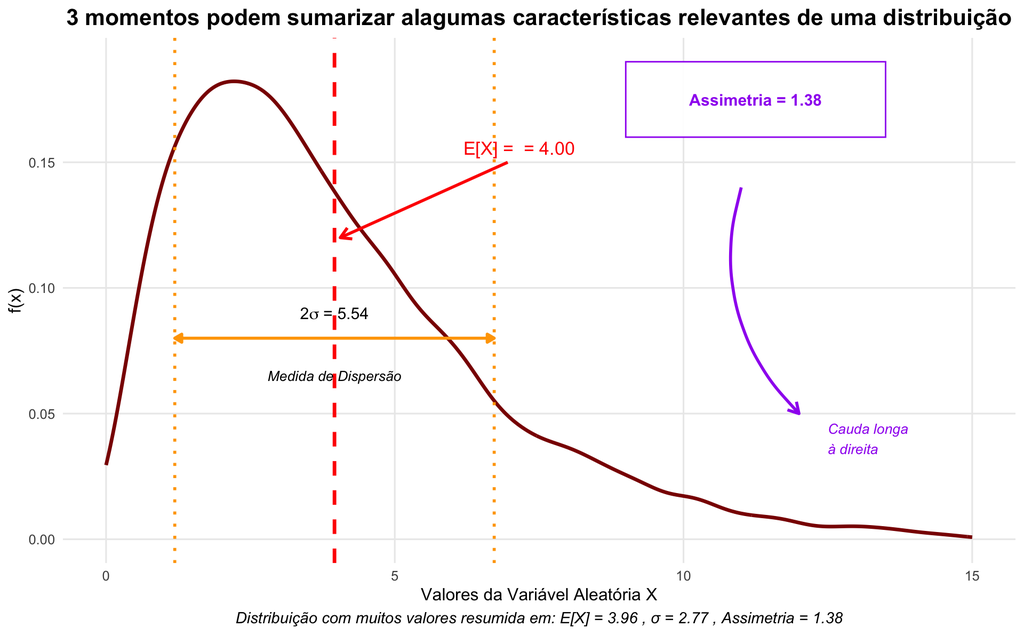

## Momentos de uma Distribuição

**Motivação**

- Há muita informação em uma função (densidade) de probabilidade
- Às vezes, informação demais.
- Talvez não nos importemos exatamente com qual é o formato da  
  distribuição, mas apenas queiramos resumir algumas de suas características mais marcantes:
  - onde ela está centralizada;
  - quão dispersa está;
  - onde atinge seu pico;
  - se é simétrica ou assimétrica;
  - quão pesadas são suas caudas.
- Podemos definir os **momentos** de uma distribuição para nos ajudar a **resumir** (ou **sumarizar**) algumas dessas características mais marcantes.

## Momentos de uma Distribuição

**Definição**

Os momentos de uma distribuição são os valores esperados das potências de $X$. Definimos momentos centrais e não centrados.

#### Observações

- Os momentos (não centrados) são os valores esperados das variáveis $X^m$
- Os momentos centrais são os valores esperados de $(X - E(X))^m$
- O primeiro momento central é definido como $\mu = E(X)$

## Valor Esperado

**Definição**

- O valor esperado de uma variável aleatória $X$, denotada por $E[X]$.
- Descreve o valor **típico** de $X$ quando o processo aleatório subjacente é repetido muitas vezes.

#### Variável Aleatória Discreta

$$E[X] = \mu = \sum_{i = 1}^{\infty} X_i \cdot P(X = x_i)$$

quando a série for ***convergente**.

#### Variável Aleatória Contínua

$$E[X] = \mu = \int_{-\infty}^{\infty} x \cdot f(x) \, dx$$

quando a integral for **convergente**.

#### Importante

- É importante entender que, embora $X$ seja uma VA, o valor esperado $E[X]$ não é uma VA. É uma característica fixa da distribuição.
- Entretanto, é útil considerar $E[Y|X]$ uma VA, como veremos adiante.

## Moda

**Definição**

Seja $X$ uma VA contínua com função densidade de probabilidade $f_X(x)$.  
A **moda** de $X$, denotada por $\text{moda}(X)$, é o valor $x^*$ tal que:

$$x^* = \arg\max_{x} f_X(x)$$

Isto é, a moda é o ponto em que a função densidade de probabilidade atinge seu valor máximo.

- Para distribuições **unimodais**, existe um único $x^*$.
- Para distribuições **multimodais**, existem vários valores de $x$ que maximizam $f_X(x)$.
- Em distribuições **uniformes contínuas**, todos os pontos no intervalo têm a mesma densidade, logo **não existe moda única**.

## Modalidade de uma VA

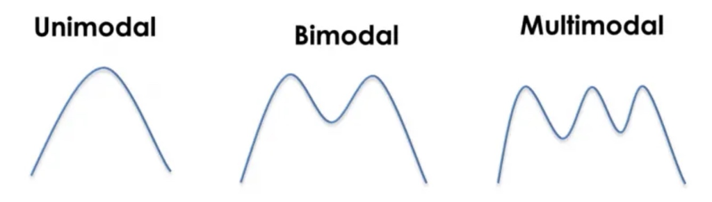

Distribuição unimodal, bimodal e multimodal.

## Variância

**Definição**

A variância é uma medida da variabilidade (dispersão) de uma VA. Ela mede o desvio quadrático em relação ao valor esperado (média):

$$V(X) = \sigma^2 = E[(X - E(X))^2] = E[(X - \mu)^2]$$

Portanto, $\sigma^2 \geq 0$

#### Representação alterantiva

Muitas vezes é útil obter $V(X)$ pela seguinte expressão:

$$V(X) = \sigma^2 = E(X^2) - E(X)^2$$

## Variância

**Teorema: $V(X) = E(X^2) - [E(X)]^2$**

**Prova** assumindo que $E(X^2)<\infty$)

$$\begin{aligned}
V(X)
&= E\!\left[(X - E(X))^2\right] \\[4pt]
&= E\!\left[X^2 - 2X\,E(X) + E(X)^2\right]
\quad\text{(expansão do quadrado)} \\[6pt]
&= E[X^2]
- 2\,\underbrace{E\!\left[X\,E(X)\right]}_{\substack{E(X)\ \text{é constante} \\ E(cY)=cE(Y)}}
+ \underbrace{E\!\left(E(X)^2\right)}_{\substack{\text{constante:} \\ E(c)=c}} \\
&= E(X^2) - 2E(X)E(X) + E(X)^2 \\
&= E(X^2) - 2E(X)^2 + E(X)^2 \\
&= E(X^2) - [E(X)]^2
\end{aligned}$$

## Desvio-Padrão

**Definição**

- O desvio-padrão, denotando por $\sigma$, é a raíz quadrada da variância:

$\sigma = \sqrt{V(X)} = \sqrt{\sigma^2} = \sigma$

- As unidades da variância são as unidades quadradas da VA, $\sigma$ é uma medida mais natural de variabilidade de uma VA.

## Padronizando uma VA

**Descrição**

- Quando uma VA $X$ possui $E(X) = \mu$ e desvio-padrão $\sigma$, sua versão **padronizada** possui:

$$E\biggl[\frac{X - \mu}{\sigma}\biggr] = \frac{E(X) - \mu}{\sigma} = \frac{\mu - \mu}{\sigma} = 0$$

$$V\biggl[\frac{X - \mu}{\sigma}\biggr] = V\biggl[\frac{X}{\sigma} - \frac{\mu}{\sigma}\biggr]= V\biggl[\frac{X}{\sigma}\biggr] = \frac{1}{\sigma^2}V(X) = \frac{\sigma^2}{\sigma^2} = 1$$

- Portanto, uma VA **padronizada** possui $E(X) = 0$ e $V(X) = \sigma = 1$.
- Os dois últimos momentos são versões padronizadas de momentos centrais.

## Assimetria

**Descrição**

- A assimetria de uma VA $X$ é o seu **terceiro momento padronizado**:

$$ass(X) = E\biggl[ \biggl(\frac{X - \mu}{\sigma}\biggr)^3 \biggr] = \frac{E[(X - \mu)^3]}{\sigma^3}$$

- A padronização torna a assimetria comparável entre distribuições com diferentes primeiro e segundo momentos, i.e, a assimetria é independente da unidade de medida por construção.
- $ass(X)$ mede a assimetria em uma distribuição, pois a terceira potência depende do sinal da diferença.
- Valores negativos da assimetria indicam que a chance de observar um valor negativo grande (em magnitude) é maior do que a chance de observar um valor positivo similarmente grande, e vice-versa.

## Assimetria

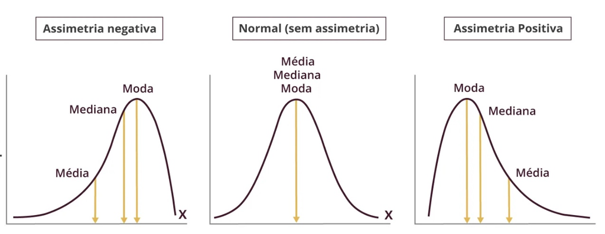

## Curtose

**Descrição**

- A curtose de uma VA $X$ é o seu **quarto momento padronizado**:

$$curtose(X) = E\biggl[ \biggl(\frac{X - \mu}{\sigma}\biggr)^4 \biggr] = \frac{E[(X - \mu)^4]}{\sigma^4}$$

- A curtose de uma VA é comumente comparada com a de uma VA com distribuição normal, que é 3.
- VAs com curtose maior que 3, uma característica comum de distribuições de retornos financeiros, são descritas como tendo caudas pesadas/grossas.
- Assim como a assimetria, a curtose é naturalmente independente de unidades e pode ser diretamente comparada entre variáveis aleatórias com diferentes médias e variâncias.

## Curtose

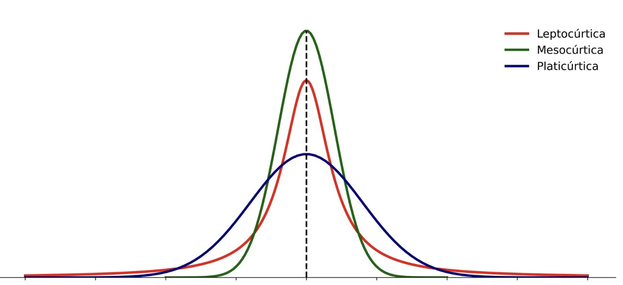

## Densidade Empírica (ou Kernel da Densidade)

**O que é um gráfico de densidade empírica?**

- Um gráfico da densidade empírica dos dados é uma representação visual que estima a função densidade de probabilidade de uma variável numérica contínua.
- Diferente do histograma, que agrupa os dados em intervalos mostra a frequência absoluta de cada intervalo, o gráfico de densidade suaviza os dados para formar uma curva contínua.
- Este tipo de gráfico é gerado através de um processo conhecido como  
  **estimativa do kernel da densidade**.
- A ideia básica por trás da estimação do kernel de uma densidade é suavizar os pontos de dados individuais em toda a região do espaço de dados, de forma a obter uma estimativa contínua para a função de probabilidade.
- Isso é feito utilizando uma função conhecida como “**kernel**”, que distribui o peso dos pontos de dados ao longo de um intervalo de valores, com o maior peso geralmente no centro e diminuindo conforme se afasta do ponto central.

Um dos kernels mais comuns é o kernel gaussiano:

$$K(x) = \frac{1}{\sqrt{2 \pi}} \exp \left(-\frac{x^2}{2}\right)$$

- A estimativa da densidade $f(x)$ em um ponto $x$ é dada por:

$$f(x) = \frac{1}{nh}\sum_{i=1}^{n} K\left(\frac{x - x_i}{h}\right)$$

sendo:

- $n$ o número de pontos de dados,
- $x_i$ são os dados,
- $K$ é a função do kernel,
- $h$ é a largura da banda ou intervalo (*binwidth*), um parâmetro crítico que controla o grau de suavização da estimativa da densidade.

## Análise de uma Densidade Empírica

**Diretrizes para Análise**

**1. Forma da Distribuição**

Classifique como simétrica, assimétrica à direita/esquerda, unimodal, bimodal ou uniforme, e avalie as implicações.

**2. Tendência Central**

Identifique onde se concentram os valores e relacione com média e mediana, essas medidas indicam um valor ou intervalo no qual a maioria dos dados se concentram, revelando o comportamento típico da variável.

**3. Variabilidade dos Dados e hiatos**

Avalie a variabilidade. Observe lacunas ou concentrações específicas.

**4. Estatísticas Descritivas Complementares**

Calcule e interprete média, mediana, desvio-padrão, assimetria e curtose para confirmar e quantificar os padrões observados visualmente na densidade

**5. Valores Atípicos**

Detecte picos isolados nas extremidades e avalie suas implicações.

**6. Interpretação Contextual**

Relacione padrões observados com conhecimento da área de aplicação e suas implicações práticas.

**7. Limitações da Análise**

Reconheça limitações da análise visual e comente sobre adequação do número da largura da banda.

## Pacote `tidyquant`

**Pacote `tidyquant`**

- O pacote `tidyquant` integra os melhores pacotes da linguagem R para coletar, manipular e analisar dados financeiros com o `tidyverse`.
- Como o tidyquant é possível realizar análises financeiras completas usando a sintaxe do `tidyverse`.
- A função `tq_get()` do pacote `tidyquant` é uma muito útil para coletar dados financeiros de diversas fontes, como Yahoo Finance, FRED, entre outras.

## Função `tq_get()`

**Função `tq_get()`**

- A sintaxe básica da função `tq_get()` é:

```r
tq_get(x, from = NULL, to = NULL, ...)
```

Onde:

- `x`: é um vetor de tickers das ações ou o nome do índice que você deseja obter os dados.
- `from`: é a data de início para a coleta dos dados (formato “YYYY-MM-DD”).
- `to`: é a data de término para a coleta dos dados (formato “YYYY-MM-DD”).

A função retorna um data frame com as colunas:

- `symbol`: é o ticker da ação ou do índice.
- `date`: é a data da observação.
- `open`: é o preço de abertura da ação no dia.
- `high`: é o preço mais alto da ação no dia.
- `low`: é o preço mais baixo da ação no dia.
- `close`: é o preço de fechamento da ação no dia.
- `volume`: é o volume de ações negociadas no dia.

# Funções de Variáveis Aleatórias

## Funções de Variáveis Aleatórias

**Por que precisamos de uma base em probabilidade para Econometria?**

- Porque não podemos compreender sobre como **funções de** **variáveis aleatórias** se comportam até que saibamos como **variáveis aleatórias** se comportam.
- E não podemos falar sobre **estatísticas**, como a **média amostral**, até que saibamos sobre **funções de variáveis aleatórias**, porque é exatamente isso que uma estatística é.
- Então agora faremos uma breve discussão sobre **funções de variáveis** **aleatórias.**

## Funções de Variáveis Aleatórias

**Situação Geral**

- Se $X$ é uma variável aleatória e $Y = h(x)$ para alguma função $g: \mathcal{X} \rightarrow \mathcal{Y} \subset \mathbb{R}$, então $Y$ também é uma variável aleatória (*)
- Qual é a distribuição de $Y = h(x)$?

(*) Para ver isso formalmente, já que $X$ é um mapeamento do espaço amostral $S$ para $\mathcal{X}$, e $g$ mapeia $\mathcal{X}$ para $\mathcal{Y} \subset \mathbb{R}$, então $Y$ também é um mapeamento de $S$ para $\mathbb{R}$.

## Funções de Variáveis Aleatórias

**Exemplo 1: Visão Gráfica**

- Queremos saber distribuição de $Y = |2X| + 3$, sendo que a fdp de $X$ é dada por: $f_X(x) = 1 - |x|$ para $-1 \leq x \leq 1$
- A fdp de $X$ é (Já vimos esta distribuição?)

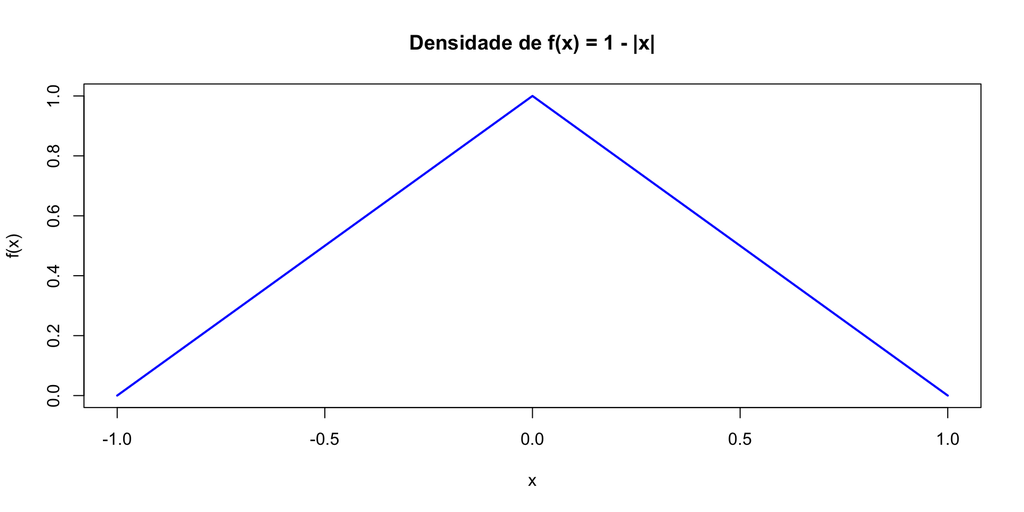

#### Passo 1: 2 $\cdot$ $X$

Veja o que acontece quando multiplicamos $X$ por 2, o suporte da fdp é “esticado” e a altura da moda é “rebaixada” (Por que?)

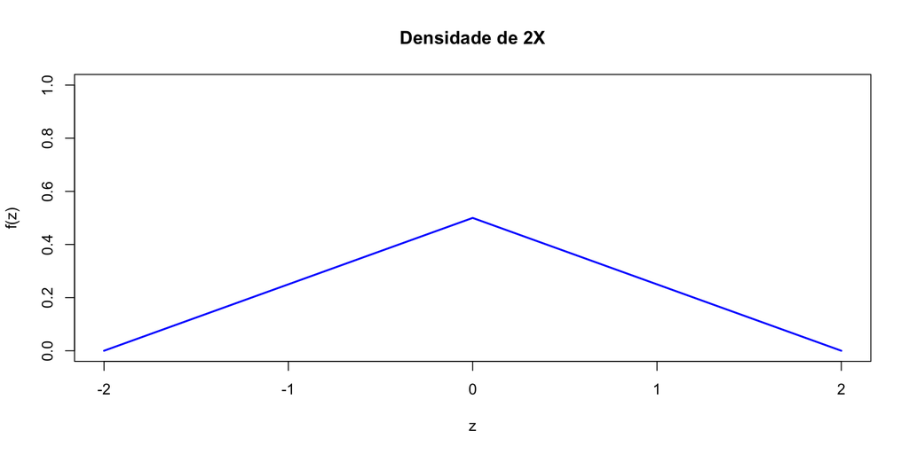

#### Passo 2 $|2\cdot X|$

- Agora, fazemos o valor absoluto $|2\cdot X|$
- toda a densidade que estava nos valores negativos é “dobrada” sobre os valores positivos:

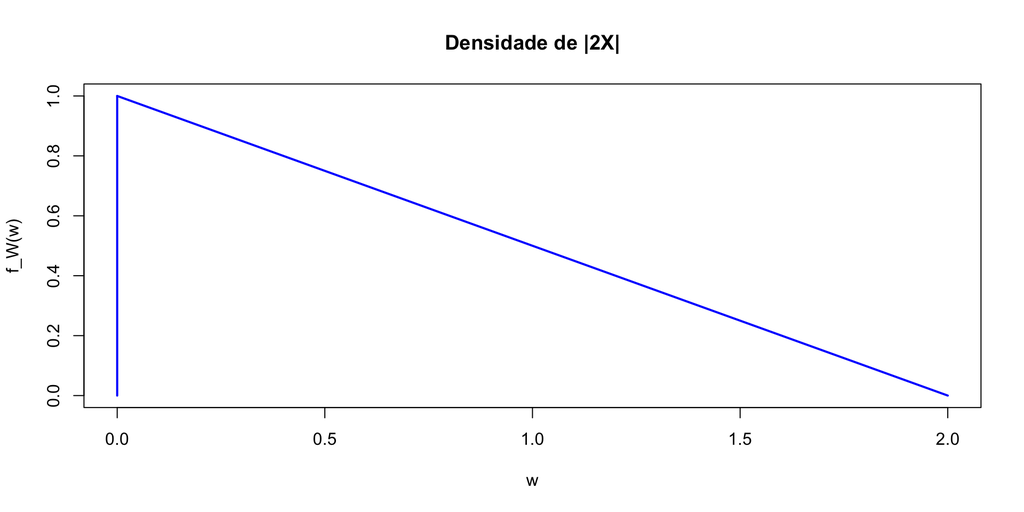

#### Passo 3: $|2\cdot X| + 3$

- Agora, finalmente, vamos adicionar 3
- Isso desloca toda a distribuição para a direita:

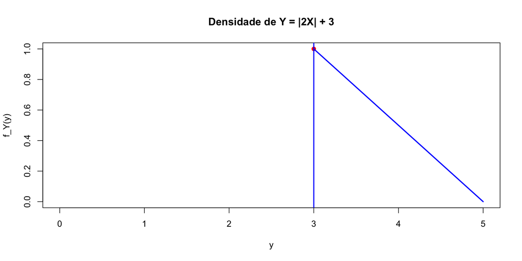

#### Considerações Finais

Tenha em mente que, durante todo esse processo, a distribuição sempre manteve as propriedades de uma FDP, em particular, a integral de cada densidade é igual a 1.

```r
# Densidade original: X ~ T(-1, 0, 1)
f_X <- function(x) {
  ifelse(abs(x) <= 1, 1 - abs(x), 0)
}

# Integral de f_X no suporte [-1, 1]
int_fx <- integrate(f_X, lower = -1, upper = 1)
int_fx$value
```

```
[1] 1
```

```r
# Densidade de Z = 2X
f_Z <- function(x) {
  ifelse(abs(x) <= 2, 0.5 - abs(x)/4, 0)
}

# Integral de f_Z no suporte [-2, 2]
int_fz <- integrate(f_Z, lower = -2, upper = 2)
int_fz$value
```

```
[1] 1
```

```r
# Densidade de W = |2X|
f_W <- function(x) {
  ifelse(x >= 0 & x <= 2, 1 - x/2, 0)
}

# Integral de f_W no suporte [0, 2]
int_fw <- integrate(f_W, lower = 0, upper = 2)
int_fw$value
```

```
[1] 1
```

```r
# Densidade de Y = |2X| + 3
f_Y <- function(x) {
  ifelse(x >= 3 & x <= 5, (5 - x)/2, 0)
}

# Integral de f_Y no suporte [3, 5]
int_fy <- integrate(f_Y, lower = 3, upper = 5)
int_fy$value
```

```
[1] 1
```

## Funções de Variáveis Aleatórias

**Há um método para descobrir a distribuição de $Y = h(X)$?**

- Existem vários métodos que podem ser usados para descobrir a distribuição de uma função de variáveis aleatórias.
- Os métodos aplicáveis a um problema específico dependem de se a variável aleatória original é discreta ou contínua, de se há apenas uma variável aleatória ou um vetor aleatório e de se a função é ou não invertível.
- Certamente não veremos todos os métodos nesse minicurso, mas aprenderemos um método importante e exemplos importantes e gerais deste método.

## Funções de Variáveis Aleatórias

**Método em 2 Passos**

#### Setup Padrão de Problema

- $X$ é uma variável aleatória com FDP $f_X{x}$ conhecida e precisamos saber a distribuição de $Y = h(X)$, então:

#### Passo 1: Encontre a FDA de $Y$ integrando $f_X{x}$ na região apropriada

$$F_Y(y) = \int_{\{ x: h(x) \leq y\}} f_X(x) dx$$

#### Passo 2: Se $Y$ for contínua, tomamos a derivada de $F_Y$ para obter a FDP de $Y$

$$f_Y(y) = \frac{d}{dy} F_Y(y)$$

## Funções de Variáveis Aleatórias

**Método em 2 Passos: Exemplo**

Seja a FDP da variável aleatória $X$ dada por:
$$f_X(x) =
\begin{cases}
1/2, & -1 \leq 0 \leq 1, \\
0, & \text{caso contrário}.
\end{cases}$$

E que precisamos encontrar a distribuição de $Y = X^2$.

#### Passo 1: Encontre a FDA de $Y$ integrando $f_X$ na região apropriada

- Lembre-se que precisamos “integrar na região apropriada”, talvez seja mais fácil falar do que fazer, mas um gráfico sempre ajuda!

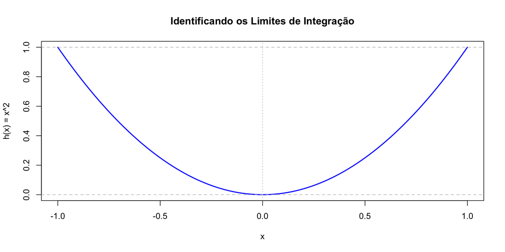

- Observe que o suporte de $X$ é $[-1,1]$, o que implica que o suporte induzido de $Y$ é $[0,1]$, usaremos isso adiante.

$$\begin{align*}
F_Y{y} &= P(Y \leq y) \, \text{(por definição)}, \\
&= P(X^2 \leq y) \, \text{(resolvemos para x)} \\
&= P(- \sqrt{y} \leq X \leq \sqrt{y}), \\
&= \int_{-\sqrt{y}}^{\sqrt{y}} \frac{1}{2} dx \, \text{(integrando na região apropriada)} \\
&= \sqrt{y}, \text{para 0 $\leq$ y $\leq$ 1} \, \text{(suporte induzido de $y$)}
\end{align*}$$

Para ser mais completo, a FDA de $Y$ é dada por:

$$F_Y(y) =
\begin{cases}
0, & y < 0, \\
\sqrt{y}, & 0 \leq y \leq 1, \\
1, & y > 1.
\end{cases}$$

#### Passo 2: Encontre a FDP de $Y$ pela derivada de $F_Y$

Como $Y$ é contínua, podemos derivar $F_Y(y)$ para obter a FDP de $Y$:

$$f_Y(y) = \frac{d}{dy} F_Y(y) =
\begin{cases}
\frac{1}{2\sqrt{y}} & \text{para 0 $\leq$ y $\leq$ 1} \\
0 & \text{caso contrário}
\end{cases}$$

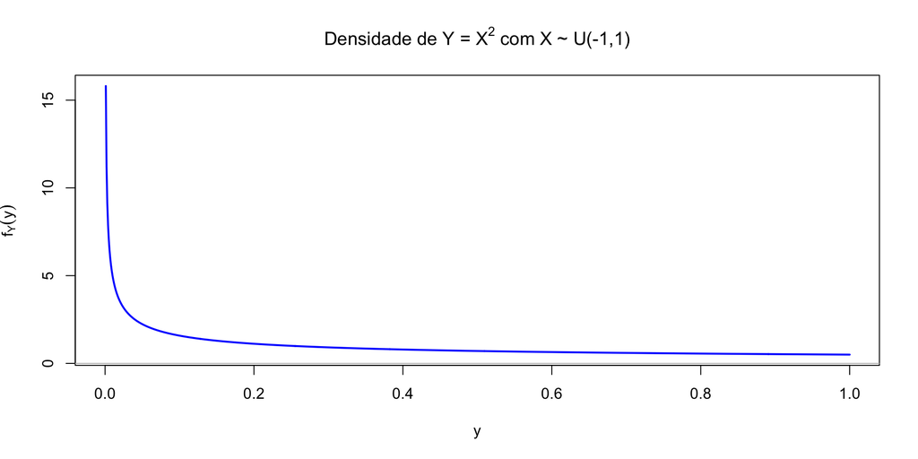

#### Observação: Reconhecendo a distribuição obtida

A densidade encontrada para $Y = X^2$ foi

$$f_Y(y) =
\begin{cases}
\dfrac{1}{2\sqrt{y}}, & 0 \leq y \leq 1, \\[6pt]
0, & \text{caso contrário}.
\end{cases}$$

Essa densidade não é “nova”: ela pertence à família **Beta** de distribuições.

A distribuição **Beta** com parâmetros $\alpha > 0$ e $\beta > 0$ é definida em $0 < y < 1$ por:

$$f(y;\alpha,\beta) = \frac{1}{B(\alpha,\beta)} \, y^{\alpha-1} (1-y)^{\beta-1},$$

onde $B(\alpha,\beta)$ é a função Beta, que serve para normalizar a densidade (isto é, garantir que a integral seja 1).

- O parâmetro **$\alpha$** controla o comportamento da densidade perto de $0$.
- O parâmetro **$\beta$** controla o comportamento da densidade perto de $1$.
- Diferentes valores de $(\alpha,\beta)$ produzem uma enorme variedade de formatos de distribuições no intervalo $[0,1]$.

No nosso caso,
$$f_Y(y) = \frac{1}{2\sqrt{y}} \quad \Longrightarrow \quad Y \sim \text{Beta}\!\left(\tfrac{1}{2},1\right).$$

Isso mostra que, ao aplicar transformações em variáveis aleatórias simples como a uniforme, podemos obter distribuições **importantes e conhecidas**.

## Transformação Linear

**Por que estudar transformações lineares de VA?**

- Pode haver muitas razões pelas quais nos importamos com a distribuição de uma transformação linear de uma variável aleatória.
- E eransformações lineares aparecem de forma natural em modelos fundamentais de finanças e econometria:
  - O retorno de uma carteira é uma combinação linear dos retornos dos ativos. Para entender risco e retorno da carteira, precisamos entender a distribuição dessa transformação.
  - O CAPM preve que o retorno de um ativo arriscado é uma função linear do retorno do mercado.
- Mudanças de unidade, moeda ou forma de expressão (índice → retorno percentual) afetam a distribuição de forma previsível via transformações lineares.
- E qual é a principal ferramenta em econometria mesmo? Modelo de Regressão Linear

## Transformação Linear

**Problema Geral**

- Seja a fdp de $X$ dada por $f_X(x)$.
- Seja $Y = aX + b$ ($a \neq 0$). Qual a distribuição de $Y$?

**Pela FDA:**
$$F_Y(y) = P(Y \le y) = P(aX + b \le y) =
\begin{cases}
P\!\left(X \le \dfrac{y-b}{a}\right), & a > 0,\\[6pt]
P\!\left(X \ge \dfrac{y-b}{a}\right), & a < 0.
\end{cases}$$

Portanto,
$$F_Y(y) =
\begin{cases}
\displaystyle \int_{-\infty}^{\frac{y-b}{a}} f_X(x)\,dx, & a>0,\\[10pt]
\displaystyle \int_{\frac{y-b}{a}}^{\infty} f_X(x)\,dx
= 1-\int_{-\infty}^{\frac{y-b}{a}} f_X(x)\,dx, & a<0.
\end{cases}$$

Tomando a derivada de $F_Y$ (regra da cadeia), obtemos a fdp de $Y$:
$$f_Y(y) = \frac{d}{dy}F_Y(y) =
\begin{cases}
\displaystyle \frac{1}{a}\,f_X\!\left(\frac{y-b}{a}\right), & a>0,\\[10pt]
\displaystyle -\frac{1}{a}\,f_X\!\left(\frac{y-b}{a}\right), & a<0,
\end{cases}$$

o que se escreve de forma compacta (regra do jacobiano):
$$\boxed{\,f_Y(y) \;=\; \frac{1}{|a|}\,f_X\!\left(\frac{y-b}{a}\right).\,}$$

## Transformação Linear

**Método dos 2 Passos: Derivando as densidades de $2X$, $|2X|$ e $|2X| + 3$**

$X$ é dada por: $f_X(x) = 1 - |x|$ para $-1 \leq x \leq 1$:

#### Densidade de $Z = 2X$

Transformação linear $Z = aX$ com $a=2$:

$$f_Z(z) = \frac{1}{|a|}\, f_X\!\left(\frac{z}{a}\right)
= \tfrac{1}{2} f_X\!\left(\tfrac{z}{2}\right).$$

Substituindo $f_X(x) = 1 - |x|$ em $-1 \le x \le 1$ (isto é, $-2 \le z \le 2$):

$$\boxed{\,f_Z(z) = \tfrac{1}{2}\Bigl(1 - \Bigl|\tfrac{z}{2}\Bigr|\Bigr)
= \tfrac{1}{2} - \tfrac{|z|}{4}, \quad -2 \le z \le 2,\,}$$

e $f_Z(z)=0$ fora desse intervalo.

#### Densidade de $W = |2X| = |Z|$

Para $w \ge 0$:

Quando definimos $W = |Z|$, cada valor positivo $w$ de $W$ pode vir de **dois valores possíveis** de $Z$:

- $z = w$
- $z = -w$

Logo, pela regra de mudança de variáveis:

$$f_W(w) = f_Z(w)\cdot\left|\frac{dz}{dw}\right| + f_Z(-w)\cdot\left|\frac{dz}{dw}\right| = f_Z(w) + f_Z(-w),$$

pois a derivada $|dz/dw| = 1$.

**Por que $f_Z$ é par?**

A densidade original $f_X(x) = 1-|x|$ é uma função **simétrica em torno de 0**.  
A transformação linear $Z=2X$ apenas estica o eixo, preservando a simetria.  
Logo, $f_Z(z) = f_Z(-z)$.

**Consequência:**

Como $f_Z(z)$ é par, $f_Z(w)=f_Z(-w)$, então:

$$f_W(w) = f_Z(w)+f_Z(-w) = 2f_Z(w), \quad w\ge0.$$

Substituindo a forma de $f_Z$:

$$\boxed{f_W(w) = 1-\tfrac{w}{2},\quad 0\le w\le 2,}$$

e $f_W(w)=0$ fora desse intervalo.

#### Densidade de $Y = |2X| + 3$

Translação $Y = W + 3$ ($a=1$, $b=3$):

$$f_Y(y) = f_W(y-3),$$

logo, com $3 \le y \le 5$,

$$\boxed{\,f_Y(y) = 1 - \frac{y-3}{2} = \frac{5 - y}{2}, \quad 3 \le y \le 5,\,}$$

e $f_Y(y)=0$ fora desse intervalo.

## Transformada Integral da Probabilidade

**Problema Geral**

- Sejam a fdp e FDA de $X$, uma VA contínua, dadas por $f_X(x)$ e $F_X(x)$.
- Seja $Y = F_X(x)$. Qual a distribuição de $Y$?
- É estranho usarmos uma FDA, que descreve a distribuição de uma variável aleatória, para transformar uma variável aleatória. É estranho usarmos uma CDF, que descreve a distribuição de uma variável aleatória, para transformar uma variável aleatória. Mas por que não? É uma função.
- Primeiro, observe que, qualquer que seja o suporte de $X$, $Y$ reside em $[0,1]$. Por quê? Porque FDAs sempre têm valores entre 0 e 1.
- Note também que $F_X$ é invertível (sabemos que $F_X$ é não decresceente, mas ela será invertível se $X$ for contínua em um intervalo conectado.)

#### Solução

Para $y \in[0,1]$, defina **explicitamente**

$$x \;=\; F_X^{-1}(y).$$

Isto significa: $x$ é um ponto no **espaço de $X$** tal que $F_X(x)=y$.

Agora, calculemos $F_Y(y)$:

$$\begin{align*}
F_Y(y) &= P(Y \le y) && \text{(definição de FDA de $Y$)}\\[6pt]
&= P(F_X(X) \le y) && \text{(substituímos $Y=F_X(X)$)}\\[6pt]
&= P(X \le F_X^{-1}(y)\big) && \text{(resolvemos a desigualdade $F_X(X)\le y$ para $X$)}\\[6pt]
&= P(X \le x) && \text{(por def., $x=F_X^{-1}(y)$ está no espaço de $X$)}\\[6pt]
&= F_X(x) && \text{(definição de FDA de $X$: $F_X(x) =P(X\le x)$)}\\[6pt]
&= F_X(F_X^{-1}(y)\big) && \text{(substituição de $x=F_X^{-1}(y)$)}\\[6pt]
&= y, && \text{(por definição de inversa/quantil: $F_X(F_X^{-1}(y))=y$).}
\end{align*}$$

Assim $F_Y(y)=y$ para $0\le y\le 1$.

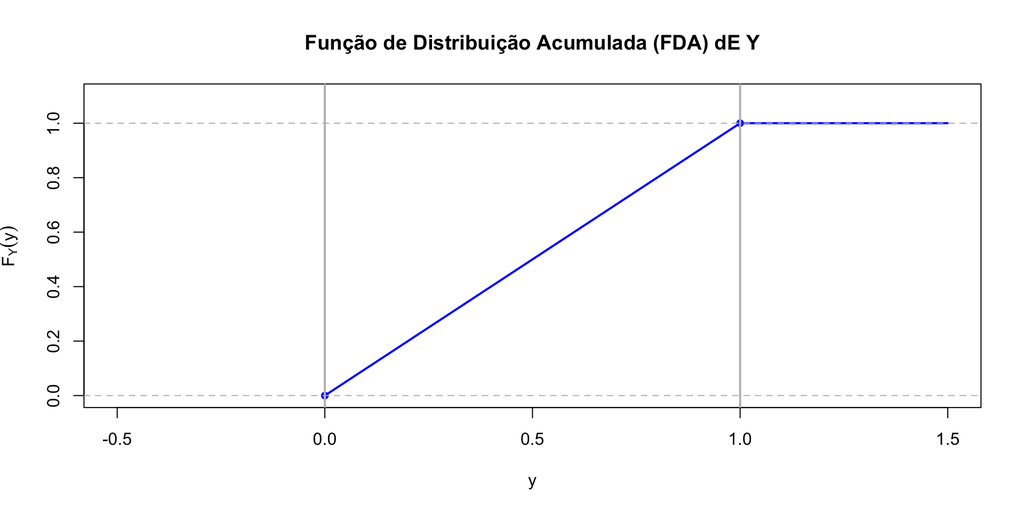

- Que variável aleatória tem uma FDA parecida com essa?

#### Resultado 1

- **Resposta:** Uma variável aleatória com distribuição $U[0,1]$ possui uma FDA como essa.
- Portanto, uma variável aleatória contínua transformada por sua própria FDA **sempre terá** uma distribuição $U[0,1]$.

#### Resultado 2

- E o contrário? Podemos transformar uma variável aleatória $U[0,1]$ pela inversa de uma FDA e obter uma variável aleatória com essa FDA?
- **Resposta:** Sim! Assumindo que a variável aleatória é contínua e atende a condições certas condições de regularidade.
- Interessante, talvez, mas como isso poderia ser útil?

## Transformada Integral da Probabilidade

**Aplicação do Resultado 2: Simulações Computacionais**

- Suponha que estivéssemos escrevendo um programa de computador para simular, digamos,a propagação de um vírus ao longo do tempo em uma população escolar.
- Para realizar a simulação, precisaríamos de amostras aleatórias de uma distribuição **uniforme** para modelar a proporção da população escolar que foi infectada inicialmente,
- Simular amostras aleatórias de uma distribuição **exponencial** para modelar a proximidade física das crianças durante uma aula de Educação Física
- Simular amostras aleatórias de uma distribuição **beta** para modelar a umidade dentro da escola em dias diferentes.
- Mas suponha que o software você estava usando poderia simular apenas amostras aleatórias de $U[0,1]$

## Transformada Integral da Probabilidade

**Aplicação do Resultado 2**

#### Simulando uma VA com Distribuição Exponencial

Agora, sabemos que se $U \sim U(0,1)$, podemos gerar uma VA $X$ com FDA $F_X$ usando:

$$X = F_X^{-1}(U)$$

A FDA de uma VA $X$ com $\text{Exponencial}(\lambda)$ é dada por:

$$F_X(x) = 1 - e^{-\lambda x}, \quad x \geq 0$$

A **Transformada Integral da Probabilidade** nos diz que podemos gerar amostras de $X$ se:

$$X = F_X^{-1}(U), \quad \text{com } U \sim \mathcal{U}(0,1)$$

#### Invertendo a FDA

Resolvendo para $x$:

$$\begin{align*}
u &= 1 - e^{-\lambda x} \\
e^{-\lambda x} &= 1 - u \\
-\lambda x &= \ln(1 - u)\, \text{(aplicamos ln a ambos os lados)} \\
x &= -\frac{1}{\lambda} \ln(1 - u)
\end{align*}$$

Obs: Se $X \sim U(0,1)$, então $1 - X$ também possui distribuição uniforme, por que?

Em R:

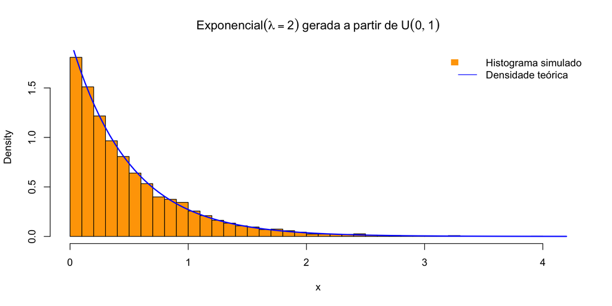

```r
set.seed(42)
u <- runif(10000)
lambda <- 2
x <- -log(u) / lambda

hist(
  x, breaks = 30, col = "orange", probability = TRUE,
  main = expression(Exponencial(lambda==2)~gerada~a~partir~de~U(0,1)),
  xlab = "x"
)

curve(dexp(x, rate = lambda), add = TRUE, col = "blue", lwd = 2)

legend(
  "topright",
  legend = c("Histograma simulado", "Densidade teórica"),
  fill   = c("orange", NA),
  border = NA,
  lty    = c(NA, 1),
  col    = c(NA, "blue"),
  bty    = "n"
)
```

#### Conclusão

- Gerar variáveis **exponenciais** a partir da **uniforme** é um exemplo clássico da **transformação pela inversa da FDA**
- Esse método é também chamado de **Transformação Inversa da FDA** ([Inverse Transform Sampling](https://en.wikipedia.org/wiki/Inverse_transform_sampling))
- Essa abordagem é **generalizável** para outras distribuições, como log-normal, Weibull e até normal (com outras técnicas)
- Esse método é uma pedra fundamental dos **geradores de variáveis aleatórias** e dos métodos de simulação de Monte Carlo

## Convolução

**Descrição**

#### Encontrando $F_{X + Y}$ (FDA)

- Muitas vezes é importante ser capaz de calcular a distribuição conjunta de $X + Y$ a partir das distribuições de $X$ e $Y$ quando $X$ e $Y$ são variáveis aleatórias **independentes**.
- Suponha que $X$ e $Y$ são contínuas, $X$ tendo fdp $f_X$ e $Y$ tendo fdp $f_Y$.
- Então, sendo $F_{X + Y}(x + y) = F_{X + Y}(a)$ a FDA da distribuição conjunta de $X + Y$, temos:

$$\begin{align*}
F_{X + Y}(a) &= P(X + Y \leq a) \\
&= \int \int_{x + y \leq a} F_{X + Y}(x + y) dx dy \\
&= \int \int_{x + y \leq a} f_X(x) f_Y(y) dx dy \,\, \text{(por independência)}\\
&= \int_{-\infty}^{\infty} \int_{-\infty}^{a - y}f_X(x) f_Y(y) dx dy \\
&= \int_{-\infty}^{\infty} \Biggl[\int_{-\infty}^{a - y}f_X(x) dx\Biggr] f_Y(y) dy \\
&= \int_{-\infty}^{\infty} F_X(a - y) f_Y(y) dy
\end{align*}$$

- A FDA $F_{X + Y}$ é chamada de **convolução** das distribuições $F_x$ e $F_y$ (as FDA de $X$ e $Y$, respectivamente).

#### Encontrando $f_{X + Y}$ ($fdp$)

$$\begin{align*}
f_{X + Y}(a) &= \frac{d}{da} \int_{-\infty}^{\infty} F_X(a - y) f_Y(y) dy \\
&= \int_{-\infty}^{\infty} \frac{d}{da} (F_X(a - y)) f_Y(y) dy \\
&= \int_{-\infty}^{\infty} f(a - y)f_Y(y) dy
\end{align*}$$

## Estatísticas de Ordem

**Definição**

- As **estatísticas de ordem** de $\{X_1, X_2, \ldots, X_n \}$ são os valores ordenados em ordem crescente.
- Elas são denotadas por $\{X_{(1)}, X_{(2)},\ldots,X_{(n)}\}$.
- $X_{(1)}$ é a primeira estatística de ordem ou **mínimo**, $X_{(2)}$ é a segunda estatística de ordem (segundo menor valor), e assim por diante.
- Seja $Y_n = max\{X_1, X_2, \ldots, X_n\}$, representa o **máximo** e é chamada de n-ésima estatística de ordem.

#### FDA da n-ésima estatística de ordem (máximo)

- A distribuição mais simples é a do máximo $X_(n)$

$$\begin{align*}
F_{n}(y) &= P(Y_n \leq y) = P(X_1 \leq y \cap X_2 \leq y\cap \ldots \cap X_n \leq y) \, \text{(pela def. de $Y_n$)} \\
&= P(X_1 \leq y \cdot X_2 \leq y \cdot \ldots \cdot X_n \leq y) \, \text{(pela independência)} \\
&= F_X(y)^n \, \text{(pelas dist. idênticas)}
\end{align*}$$

#### fdp da n-ésima estatística de ordem (máximo)

Como sempre, basta obtermos a derivada da FDA para obter a fdp:

$$f_{n}(y) = \frac{d}{dy} F_n(y) = n F_X(y)^{n-1}$$

#### fdp da primeira estatística de ordem (mínimo)

Um cálculo similar mostra que para $X_{(1)}$:

$$f_1(y) = n (1 - F_X(y))^{n-1} f_X(y)$$

Então temos que:

$$\begin{align*}
f_{n}(y) &= n F_X(y)^{n-1}\, \text{(fdp da n-ésima estatística de ordem (máximo))} \\
f_1(y) &= n (1 - F_X(y))^{n-1} f_X(y) \, \text{(fdp da primeira estatística de ordem (mínimo))}
\end{align*}$$

#### Exemplo: fdp de $X_{(1)}$ e $X_{(n)}$

- Como seriam essas distribuições se tivéssemos uma amostra aleatória de, digamos, uma distribuição $U[0,1]$?
- Depende de $n$.
- Para $n = 5$, temos:

$$\begin{align*}
f_{n}(y) &= 5y^4\, (0 \leq y \leq 1) \\
f_1(y) &= 5(1 - y)^4 \, (0 \leq y \leq 1)
\end{align*}$$

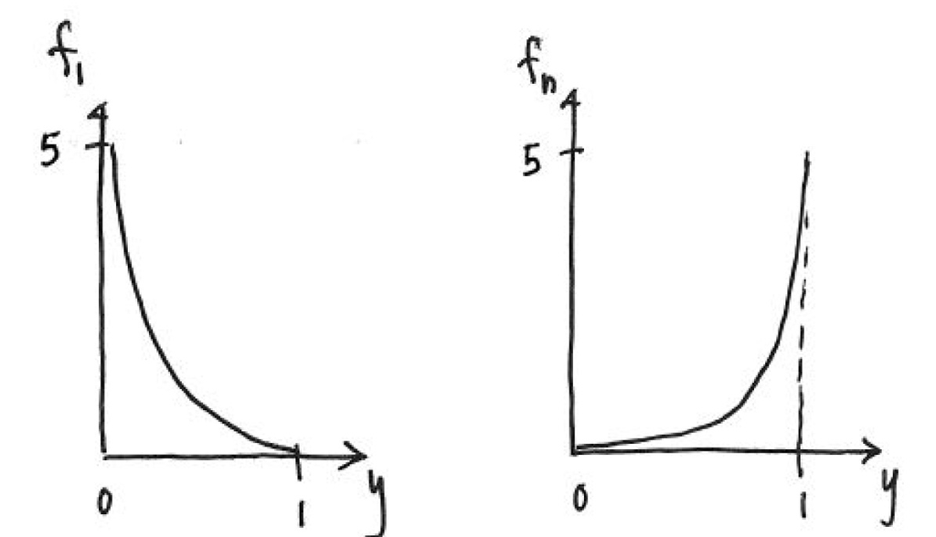

- O suporte é o mesmo ($[0,1]$), mas a medida que $n$ aumenta, a distribuição de $X_{(1)}$ tente a ficar concentrada à direita de 0 e a distribuição de $X_{(n)}$ à esquerda de 1.

## Funções de Variáveis Aleatórias

**Atenção!**

- Qualquer função de uma variável aleatória gera outra variável aleatória.
- Mas **isso não significa que a função resultante é automaticamente uma densidade válida ou conhecida**.
- Para que seja uma **função densidade de probabilidade (FDP)**, ela precisa ser **não-negativa** e integrar a 1 no seu suporte.
- Em alguns casos, a distribuição resultante pode:
  - não ter uma forma fechada simples,
  - não pertencer a nenhuma família “conhecida”,
  - ou até mesmo ser uma **distribuição mista** (parte discreta + parte contínua).

# Distribuições de Probabilidade Multivariadas

## Vetor Aleatório

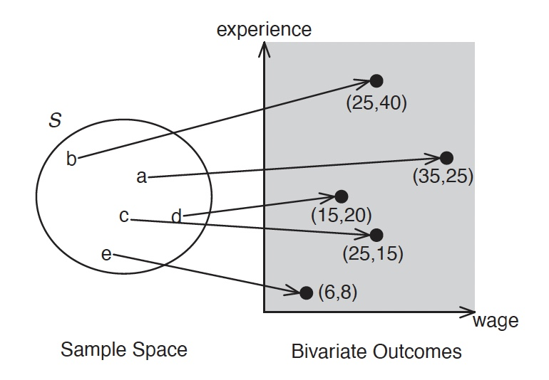

Considere o par bivariado (salário, experiência profissional). Estamos interessados em como os salários variam com a experiência e, portanto, em sua **distribuição conjunta**. O mapeamento é ilustrado nesta figura. A elipse é o espaço amostral com resultados aleatórios a, b, c, d, e. (Você pode pensar nos resultados como assalariados individuais em um ponto no tempo.) O gráfico é o quadrante positivo em $\mathbb{R^2}$ representando os pares bivariados (salário, experiência profissional). As setas representam o mapeamento. Cada resultado é um ponto no espaço amostral. Cada resultado é mapeado para um ponto em $\mathbb{R^2}$. Estes últimos são um par de variáveis aleatórias (salário e experiência). Seus valores são marcados no gráfico, com o salário medido em dólares por hora e a experiência em anos.

## Distribuições Conjunta, Marginal e Condiciional

**Definição: Caso Bivariado**

#### Distribuição Conjunta

No caso contínuo, a **fdp conjunta** do vetor aletatório $(X, Y)$ é:

$$f_{XY}(x, y) = P((X,Y) \subset A) = \int \int_{A} f_{XY}(x, y)\,dx\,dy = 1$$

E a **FDA conjunta**

$$F_{X,Y}(x, y) = P(X \leq x \cap Y \leq y) = \int_{-\infty}^{y} \int_{-\infty}^x f_{XY}(x, y)\,dx\,dy = 1$$

Usamos “conjunta” para indicar especificamente que esta é a distribuição de múltiplas variáveis aleatórias, i.e, de um vetor aleatório.

#### Distribuição Marginal

1. Dada a fdp conjunta $f(x,y)$, as densidades marginais de $X$ e $Y$ são:

$$f_X(x) = \int_{-\infty}^{\infty} f_{XY}(x, y)\,dy$$

e

$$f_Y(y) = \int_{-\infty}^{\infty} f_{XY}(x, y)\,dx$$

2. Dada a FDA conjunta $F(x,y)$, as densidades marginais de $X$ e $Y$ são:

$$f_X(x) = \frac{d}{dx} F_X(x) = \int_{-\infty}^{\infty} f_{XY}(x, y)\,dy$$

e

$$f_Y(y) = \frac{d}{dy} F_Y(y) = \int_{-\infty}^{\infty} f_{XY}(x, y)\,dx$$

Essas densidades marginais são obtidas integrando em relação à outra variável, “removendo” sua influência da densidade conjunta.

#### Distribuição Condicional

1. Dada a fdp conjunta $f_{XY}(x, y)$, a **fdp condicional** de $Y$ dado $X = x$ é:

$$f_{Y|X}(y|x) = \frac{f_{XY}(x, y)}{f_X(x)}\, \text{para qualquer $x$ tal que $f_X(x) > 0$.}$$

2. Dada a FDA conjunta $F(x,y)$, se $F_{Y|X}(y|x)$ é diferenciável em relação à $y$ e $P(X = 0) > 0$, a **fdp condicional** de $Y$ dado $X = x$ é:

$$f_{Y|X}(y|x) = \frac{\partial}{\partial y} F_{Y|X}(y|x)$$

Podemos pensar nisso como a densidade de $Y$ para a **subpopulação** com um determinado valor de $X$.

## Distribuicão Normal Bivariada

[interactive chart not shown]

## Arquivo `hansen-wage.rds`

**Fonte**

Dados utilizados em um livro de Brunce Hansen e extraídos da pesquisa *Current Population Survey (CPS - March/2009)* realizada pelo *U.S. Census Bureau*.

#### Arquivo `hansen-wage.rds`

- É uma **subamostra** dos dados princiapis
- Contém **trabalhadores civis em tempo integral**, **não imputados**, com salário-hora positivo
- Campos presentes (12 varia’veis): `age`, `female`, `hisp`, `education`, `earnings`, `hours`, `week`, `union`, `uncov`, `region`, `race`, `marital`.

#### Dicionário dos Dados

- `age`: idade (00–85 na codificação CPS).
- `education`: escolaridade** em **anos**,
- `earnings`: renda anual de **wage & salary** (pessoa).
- `hours`: horas trabalhadas por semana (pessoa).
- `week`: semanas trabalhadas no ano.
- `female`: (1=masc., 2=fem.).
- `marital`: (1..7; casado, viúvo, divorciado, etc.).
- `union`: sindicalizada(o): (1=é membro). `uncov` ← **A_UNCOV** (1=coberto por contrato).
- `region`: região (1=Nordeste, 2=Centro-Norte, 3=Sul, 4=Oeste).
- `race`: raça

#### Variáveis utilizadas

- **Salário-hora** (*Wage*):

  $$\text{wage} = \frac{\text{earnings}}{\text{hours}\times \text{week}}$$
- **Experiência** (*Experience*):

  $$\text{experience}=\max\{\text{age}-\text{education}-6,\;0\}$$
- **Educação** (*Education*): em **anos**

## Distribuição Conjunta Empírica

[interactive chart not shown]

## Densidades Condicionais Empíricas

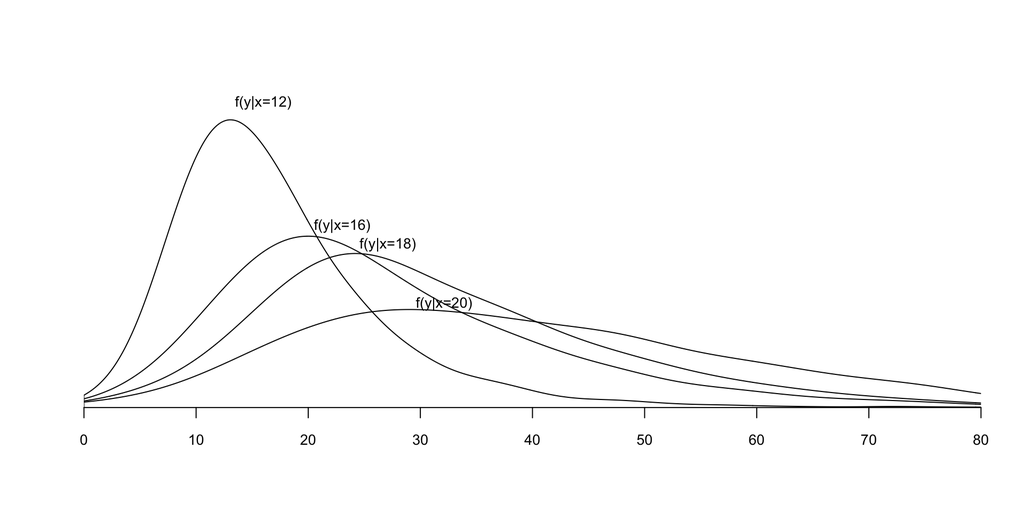

Figura 1: Densidade Condicional de Salário dada Educação.

## Densidade Condicional Empírica

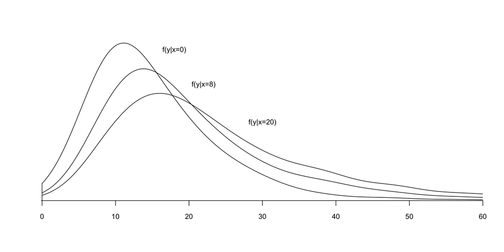

Figura 2: Densidade Condicional de Salário dada Experiência.

## Comparando as Densidades Condicionais

**Conclusão**

- Se compararmos as densidades condicionais na Figura 1 com as da Figura 2, podemos ver que o efeito da educação sobre os salários é consideravelmente mais forte do que o efeito da experiência.

## Valor Esperado Condicional

**Definição**

- É um conceito muito importante em econometria.
- Um valor esperado condicional é o valor esperado de uma distribuição condicional.

#### Caso Discreto

Para VAs discretas, temos:

$$\begin{align*}
E[Y|X=x] &= \frac{f_{x,y}(x, y)}{f_{X}(x)}
\end{align*}$$

- Quando X é discreta, a expectativa condicional é o valor esperado de $Y$ dentro da subpopulação para a qual $X = x$.
- Por exemplo, se X é sexo, então $E[Y|X = x]$ é o valor esperado para homens e mulheres, separadamente.
- Se X é educação, então $E[Y|X = x]$ é o valor esperado para cada nível educacional.

#### Caso Contínuo

Para VAs contínuas, temos:

$$\begin{align*}
E[Y|X=x] &= \int_{-\infty}^{\infty} f_{Y|X}(y|x)\,dy \\
&= \frac{\int_{-\infty}^{\infty} y f(x,y)dy}{\int_{-\infty}^{\infty} f(x,y)dy}
\end{align*}$$

- Quando $X$ é contínua, a expectativa condicional é o valor esperado de $Y$ dentro da população infinitesimalmente pequena para a qual $X = x$.

#### Importante

- A função $m(x) = E[Y|X = x]$ não é aleatória, é uma característica fixa da distribuição conjunta de $X$ e $Y$.
- Às vezes, porém, é útil tratar a expectativa condicional como uma variável aleatória.
- Outra maneira de expressar a distinção é que $m(x)$ é o valor da expectativa condicional em $X = x$, enquanto $m(X)$ é uma função (uma transformação) da variável aleatória $X$.

## Lei das Expectativas Iteradas

**Descrição**

#### Teorema: Se $E|Y| < \infty$, então $E[E[Y|X]] = E(Y)$

- Tratando $E(Y|X)$ como uma variável aleatória, podemos obter esse resultado muito crítico para modelos de regressão linear.
- O teorema diz que o ** VE incondicional** é igual ao **VE incondicional** da **função do VE condicional**.

#### Prova

Primeiro, precisamos da notação…

Seja $\mathop{f_{x,y}}(u,t)$ a densidade conjunta para VAs contínuas $\left( \text{X}_{i},\text{Y}_{i} \right)$.

Seja $\mathop{f_{y|x}}(t\mid \text{X}_{i}=u)$ a distribuição condicional de $\text{Y}_{i}$ dado $\text{X}_{i}=u$.

E sejam $\mathop{g_y}(t)$ e $\mathop{g_x}(u)$ as densidades marginais de $\text{Y}_{i}$ e $\text{X}_{i}$.

$$\begin{align*}
E\big[\,\color{#e64173}{E(Y_i|X_i)}\,\big] &= E[E(Y|X)] \\
&= \int \color{#e64173}{E(Y|X=u)}\, g_X(u)\, du \\
&= \int \color{#e64173}{\left[ \int t\, f_{Y|X}(t|u)\, dt \right]} \, g_X(u)\, du \\
&= \iint \color{#e64173}{t\, f_{Y|X}(t|u)}\, g_X(u)\, du \, \color{#e64173}{dt} \\
&= \iint \color{#e64173}{t}\, f_{X,Y}(u,t)\, du \, \color{#e64173}{dt} \\
&= \int \color{#e64173}{t}\, g_Y(t)\, \color{#e64173}{dt} \\
&= E(Y).
\end{align*}$$

- Em palavras, a média das médias dos grupos é a média geral.

## Qual é o Ponto?

**Lei das Expectativas Iteradas e Função da Esperança Condicional**

A LEI nos permite **decompor** a variável aleatória $Y_i$ em duas partes:

#### Propriedade de Decomposição FEC

$$\begin{align*}
Y_{i} \;=\; \color{#e64173}{E\!\left[ Y_{i}\mid X_{i} \right]} \;+\; \color{#6A5ACD}{\varepsilon_i}
\end{align*}$$

1. $\color{#e64173}{\text{A função da esperança condicional}}$
2. $\color{#6A5ACD}{\text{Um resíduo}}$ $\color{#6A5ACD}{\varepsilon_i}$ com super poderes:  
   $\color{#6A5ACD}{\text{i}}$. $E(\color{#6A5ACD}{\varepsilon_i}\mid X_i)=0$. $\color{#6A5ACD}{\varepsilon_i}$ é independente da média de $X_i$.  
   ii. $E[\color{#6A5ACD}{\varepsilon_i}\, h(X_i)]=0$. $\color{#6A5ACD}{\varepsilon_i}$ é não correlacionado com qualquer função de $X_i$.

#### Importante

A propriedade de decomposição da FEC diz que podemos decompor qualquer VA $Y_i$ em:

1. Uma parte que é explicada por $\color{#e64173}{\text{X}_{i}}$ (*i.e.*, a FEC $\color{#e64173}{\mathop{E}\left[ \text{Y}_{i} \mid \text{X}_{i} \right]}$)
2. Uma parte que é independente a qualquer função de $\color{#e64173}{\text{X}_{i}}$ (i.e, $\color{#6A5ACD}{\varepsilon_i}$)

## Valor Esperado

**Propriedades de $E(X)$ e de $E[Y|X]$**

1. $E(c) = c$, sendo $c$ uma constante.
2. $E[cX]=cE[X]$, se $c$ é uma constante e $X$ uma VA.
3. **Teorema (Linearidade do Valor Esperado)**: Sendo $Y = a + bX$, para $a$ e $b$ constantes, $E(a + bX) = a + bE(X)$.
4. Para $Y = X_1 + X_2 + \ldots + X_n$, temos que $E(Y) = E(X_1) + E(X_2) + \ldots + E(X_n)$. (**Nota:** As VAs não precisam ser independentes!)
5. Para $Y = a_1 X_1 + a_2 X_2 + \ldots + a_n X_n$, temos que $E(Y) = a_1 E(X_1) + a_2 E(X_2) + \ldots + a_n E(X_n)$.

## Variância

**Propriedades de $V(X)$**

1. $V(X) \geq 0$.
2. $V(c) = 0$, sendo $c$ uma constante.
3. Se $Y = a + bX$, então $V(Y) = b^2 V(X)$.
4. $V(X) = E[(X - E(X))^2] = E(X^2) - [E(X)]^2$.
5. Se $Y = X_1 + X_2 + \ldots + X_n$ e as variáveis aleatórias $X_i$ são *independentes*, então $V(Y) = V(X_1) + V(X_2) + \ldots + V(X_n)$.
6. Se $Y = a_1 X_1 + a_2 X_2 + \ldots + a_n X_n$ e as variáveis aleatórias $X_i$ são independentes, então $V(Y) = a_1^2 V(X_1) + a_2^2 V(X_2) + \ldots + a_n^2 V(X_n)$.

## Variância Condicional

**Definição**

- Outra característica da distribuição condicional é a variância condicional.

#### V(Y|X = x) - Característica Fixa

$$V(Y|X = x) = E[(Y - E(Y|X = x))^2 | X = x]$$

#### V(Y|X) - Variável Aleatória

$$V(Y|X) = E[(Y - E(Y|X))^2]$$

## Lei da Variância Total

**Teorema da Análise da Variância**

Uma outra propriedade da função do VE condicional é:

$$V(Y) =
\underbrace{E[V(Y|X)]}_{\text{variância dentro dos grupos}} +
\underbrace{V(E[Y|X])}_{\text{variância entre grupos}}$$

O primeiro termo do lado direito é frequentemente chamado de **variância dentro dos grupos**, enquanto o segundo termo é chamado de **variância entre grupos**.

Ou seja, podemos decompor a variância total de $Y$ em:

- **variância dentro dos grupos**: média das variâncias condicionais de $Y$ dado $X$
- **variância entre grupos**: variância das médias condicionais de $Y$ dado $X$
- $E[V(Y|X)]$: mede a variabilidade restante em $Y$ depois de explicar tudo que $X$ pode explicar — ou seja, os resíduos.
- $V(E[Y|X])$: mede o quanto um modelo ($E[Y|X]$) consegue explicar da variabilidade total de $Y$.

**Exemplo:** Decompomos a variação salarial em (1) variação explicada pelas características dos trabalhadores e (2) variação inexplicável (residual)

## Covariância

**Covariância**

A **covariância** entre duas variáveis aleatórias $X$ e $Y$ tendo $E(X) = \mu_X$ e $E(Y) = \mu_Y$ é uma característica des sua distribuição conjunta.

É definida como:

$$\text{Cov}(X, Y) = E[(X - \mu_X)(Y - \mu_Y)] = E(XY) - E(X)E(Y)$$

Propriedades:

- **Simétrica**: $\text{Cov}(X, Y) = \text{Cov}(Y, X)$
- $\text{Cov}(X, Y) > 0$: variáveis tendem a cresce/decrescer juntas
- $\text{Cov}(X, Y) < 0$: uma cresce, a outra decresce, e vice-versa.
- Tem unidade: $\text{unid}(X) \cdot \text{unid}(Y)$

A covariância é como a **média dos produtos de desvios conjuntos**.

## Correlação

**Definição Correlação**

A correlação entre uma variável aleatória $X$, tendo $E(X) = \mu_X$ e desvio padrão $\sigma_X$, e uma variável aleatória $Y$, tendo $E(Y) = \mu_Y$ e desvio padrão $\sigma_Y$, é definida como:

$$\text{Cor}(X, Y) =
E\left[ \left( \frac{X - \mu_X}{\sigma_X} \right)\left( \frac{Y - \mu_Y}{\sigma_Y} \right) \right] = \frac{\text{Cov}(X, Y)}{\sigma_X \sigma_Y}$$

A **correlação** padroniza a covariância, removendo as unidades e está confinada ao intervalo $[-1, 1]$, podendo fornecer uma medida da força da **relação linear** entre $X$ e $Y$.

Propriedades:

É como comparar os **desvios padronizados**: ambos estão acima da média? quanto?

## Correlação entre Variáveis Aleatórias

**Correlação**

- Quando as variáveis aleatórias $X$ e $Y$ **não são independentes**, certos valores de $X$ tendem a estar associados a certos valores de $Y$. Ou seja, existe uma **relação ou associação** entre elas.
- Ao amostrarmos aleatoriamente pares $(X, Y)$ de sua **distribuição conjunta** de probabilidade, com médias marginais $\mu_X$ e $\mu_Y$, dizemos que há uma **associação positiva** se, em média, o valor de $(X - \mu_X)(Y - \mu_Y)$ é positivo.

Em outras palavras:

- Quando $X > \mu_X$, geralmente também temos $Y > \mu_Y$;
- Quando $X < \mu_X$, geralmente também temos $Y < \mu_Y$.

Já uma **associação negativa** ocorre se, em média, o produto $(X - \mu_X)(Y - \mu_Y)$ assume valores negativos — isto é, quando $X$ está acima da média ($X > \mu_X$), tende-se a observar $Y < \mu_Y$, e vice-versa.

## Propriedades

**Covariância e da Correlação**

1. $Cov(X,X) = V(X)$
2. $Cov(X,Y) = Cov(Y,X)$
3. $Cov(X,Y) = E(XY) - E(X)E(Y)$
4. Se $X$ e $Y$ são variáveis aleatórias independentes, então $Cor(X,Y) = 0$. Entretanto, a implicação contrária não é verdadeira.
5. $Cov(aX + b, cY + d) = ac Cov(X,Y)$
6. Para *quaisquer* VAs $X$ e $Y$, temos que $V(X + Y) = V(X) + V(Y) + 2V(Cov(X,Y))$.
7. $|\rho_{XY}| \leq 1 \rightarrow -1 \leq \rho_{XY} \leq 1$
8. $|\rho_{XY}| = 1$ se, e somente se, $Y = aX + b$ ($a \neq 0$)

# Cálculo Diferencial e Integral em R

## Panorama: Ferramentas para Cálculo em R

**Objetivo**

Visão rápida de pacotes para **cálculo simbólico** e **numérico** em R — quando usar cada um e cuidados práticos.

#### O que é um CAS?

**CAS** (*Computer Algebra System*) é um sistema que **manipula expressões matemáticas simbolicamente** (deriva, integra, simplifica, resolve equações, etc.). Exemplos notáveis: **Mathematica** (provavelmente o mais difundido comercialmente), **Maple**; entre os livres, **SymPy** (Python) e **Maxima**. Em R, o pacote **Ryacas** integra o CAS **Yacas**.

#### Pacotes R

| Pacote | Foco principal | Funções típicas | Vantagens | Limitações | Quando usar |
| --- | --- | --- | --- | --- | --- |
| **Deriv** | **Derivação simbólica** em R | `Deriv()`, `Simplify()` | Leve; gera **funções R**; rápido | **Não é CAS completo**; **não** integra simbolicamente | Gradientes exatos p/ otimização, ANOVA, teoria; derivadas fechadas |
| **numDeriv** | **Derivação numérica** (aproximação) | `grad()`, `hessian()`, `jacobian()` | “Caixa-preta”; serve p/ funções opacas | Erros de aproximação; sensível a escala/passo; problemas em quinas | Otimização/ML quando forma analítica é desconhecida; validação |
| **Ryacas** | **Álgebra simbólica (CAS Yacas)** | `yac_symbol()`, `Ryacas::integrate()`, `yac_str()` | Integrais **indef./def.**; manipulação/simplificação algébrica | Pode falhar/simplificar pouco; mais pesado; conflito com `integrate()` | Necessidade de **expressões exatas**, integrais simbólicas, álgebra |

#### **Boas práticas**

- Evite colisões: use nomes qualificados — `Ryacas::integrate(expr, x, 0, 1)` (simbólica) vs. `base::integrate(function(x) x^2, 0, 1)$value` (numérica).
- Numérico: escale variáveis e evite descontinuidades; Simbólico: declare variáveis com `yac_symbol()`.

## Derivada Simbólica Simples em R

**Exemplo**

Calcular simbolicamente

$$\frac{d}{dx}\,\big(x^3 e^{x}\big).$$

## Derivada Simbólica Simples em R

```r
# Pacote para diferenciação simbólica (expressões/funções R)
library(Deriv)

# (a) Como expressão simbólica
f_expr  <- quote(x^3 * exp(x))
Dx_expr <- Deriv(f_expr, "x")
Dx_expr  # 3*x^2*exp(x) + x^3*exp(x)
```

```
x^2 * (3 + x) * exp(x)
```

```r
# (b) Como função R (útil para avaliar em pontos)
f  <- function(x) x^3 * exp(x)
Df <- Deriv(f, "x")
Df(1)     # valor da derivada em x = 1
```

```
[1] 10.873
```

## Derivada Numérica Simples em R

**Exemplo**

Estimar numericamente $f'(1)$ para $f(x)=x^3 e^{x}$ por diferenças finitas (e comparar com um método de biblioteca).

## Derivada Numérica Simples em R

```r
# pacote para diferenciar funções numericamente
library(numDeriv)

f  <- function(x) x^3 * exp(x)
h  <- 1e-6
x0 <- 1

# Diferenças centrais "na mão"
dc <- (f(x0 + h) - f(x0 - h)) / (2*h)
dc
```

```
[1] 10.873
```

```r
# Método robusto via numDeriv::grad (esquema adaptativo)
grad(f, x = x0)
```

```
[1] 10.873
```

## Derivada Simbólica Parcial em R

**Exemplo**

Calcular as derivadas parciais de

$$g(x,y) = x^2\,y + \sin(xy).$$

## Derivada Simbólica Parcial em R

```r
# Pacote para diferenciação simbólica (expressões/funções R)
library(Deriv)

g  <- function(x, y) x^2*y + sin(x*y)

# Parciais simbólicas como funções R
Dx <- Deriv(g, "x")  # ∂g/∂x = 2*x*y + y*cos(x*y)
Dy <- Deriv(g, "y")  # ∂g/∂y = x^2 + x*cos(x*y)

# Avaliar em (x, y) = (1, 2)
Dx(1, 2)
```

```
[1] 3.1677
```

```r
Dy(1, 2)
```

```
[1] 0.58385
```

```r
# Opcional: forma como expressões simbólicas
g_expr <- quote(x^2*y + sin(x*y))
Deriv(g_expr, "x")
```

```
y * (2 * x + cos(x * y))
```

```r
Deriv(g_expr, "y")
```

```
x * (cos(x * y) + x)
```

## Integral Simbólica Indefinida Simples em R

**Exemplo**

Calcular simbolicamente

$$\int x^2 \, dx.$$

## Integral Simbólica Indefinida Simples em R

```r
# Pacote para integração simbólica
library(Ryacas)

x <- yac_symbol("x")

# Integral indefinida simbólica
I_indef <- Ryacas::integrate(x^2, x)   # x^3/3 + C
I_indef
```

```
y: x^3/3
```

## Integral Simbólica Definida Simples em R

**Exemplo**

Calcular simbolicamente:

$$\int_{0}^{1} x^2 \, dx.$$

## Integral Simbólica Definida Simples em R

```r
# Pacote para integração simbólica
library(Ryacas)

x <- yac_symbol("x")

# Integral definida simbólica
I_def <- Ryacas::integrate(x^2, x, 0, 1)  # 1/3
I_def
```

```
y: 1/3
```

## Integral Simbólica Indefinida Dupla em R

**Exemplo**

Calcular simbolicamente

$$\int \int x^2 y \, dx\,dy.$$

## Integral Simbólica Indefinida Dupla em R

```r
library(Ryacas)

x <- yac_symbol("x")
y <- yac_symbol("y")

expr  <- x^2 * y

# Integra primeiro em relação a x (indefinida)
Ix   <- Ryacas::integrate(expr, x)     # (x^3*y)/3 + C
Ix
```

```
y: (x^3*y)/3
```

```r
# Agora integra o resultado em relação a y (indefinida)
Ixy  <- Ryacas::integrate(Ix, y)       # (x^3*y^2)/6 + C
Ixy
```

```
y: (y^2*x^3)/6
```

## Integral Simbólica Definida Dupla em R

**Exemplo**

Calcular simbolicamente a integral iterada

$$\int_{y=0}^{2}\!\!\int_{x=0}^{1} x^{2} y \, dx\,dy.$$

## Integral Simbólica Definida Dupla em R

```r
x <- yac_symbol("x")
y <- yac_symbol("y")

expr <- x^2 * y

# Integra em x, 0..1
Ix  <- Ryacas::integrate(expr, x, 0, 1)   # y/3
Ix
```

```
y: y/3
```

```r
# Integra em y, 0..2
Ixy <- Ryacas::integrate(Ix, y, 0, 2)     # 2/3
Ixy
```

```
y: 2/3
```

## Referências

DEVORE, J. L. **Probabilidade e Estatística para Engenharia e Ciências**. São Paulo: Thomson, 2006.